# Activity Monitoring

LVK

5/25/2022

```r
library(tidyverse)
library(lubridate)
```

```r
library(ggplot2)
```

## Loading Dataset

We’ll begin by creating a function that does the job of downloading the data from a connection.

```r
#Function to download data from a file_url and place it in an appropriate location
get_files = function (filefile_url, filePath) {
    data_folder = "./data"
    if (!dir.exists(data_folder)) {
        dir.create(data_folder)
    }

    if (!file.exists(filePath)) {
    download.file(filefile_url, destfile = filePath)
    }
}

file_url = "https://d396qusza40orc.cloudfront.net/repdata%2Fdata%2Factivity.zip"
Path = "./data/personal_activity_monitor_data.zip"

get_files(file_url, Path)
```

## Unzip to reveal contents

```r
unzip(Path, exdir = "./data")
```

## Reading the data into R

```r
monitor_df = read.csv("./data/activity.csv")
```

# Question 1

## Dates

First we will use the lubridate package to turn the date variable into a proper date time object

```r
monitor_df$datetime = ymd(monitor_df$date)
```

## Summarize steps by date

```r
steps_per_day = monitor_df %>%
      group_by(datetime) %>%
      summarise(totalsteps = sum(steps),
                meansteps = mean(steps),
                mediansteps = median(steps)
                )
```

## Plot the histogram

Here we will use a special argument stat to show that we will provide data to the y axis rather than it being generated from the count of the number of items in each bin as is the default.

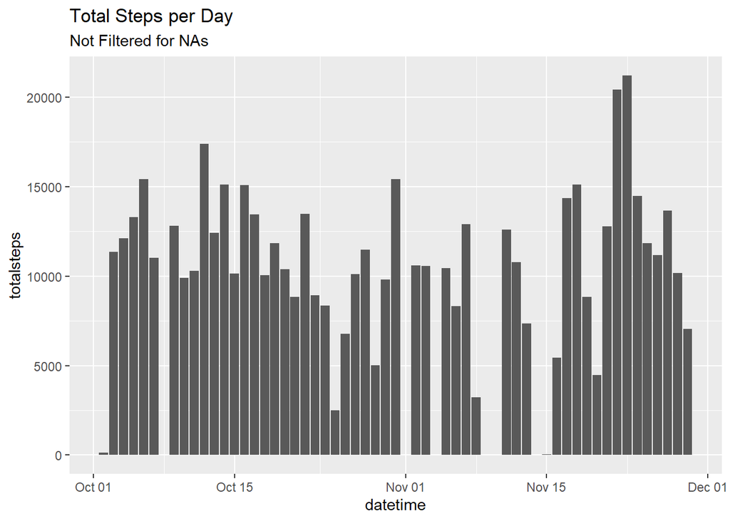

```r
ggplot(data=steps_per_day, aes(datetime, totalsteps)) +
      geom_histogram(stat='identity') +
      labs(title = "Total Steps per Day", subtitle = "Not Filtered for NAs")
```

```r
dev.copy(png, file = "hist1.png",width=480,height=480,units="px")
```

```r
dev.off()
```

```r
mean_steps = mean(steps_per_day$meansteps, na.rm = TRUE)
median_steps = median(steps_per_day$mediansteps, na.rm = TRUE)
```

# Question 2 : Time Series Data

We will group by the interval and get the average across all the days. Then we plot.

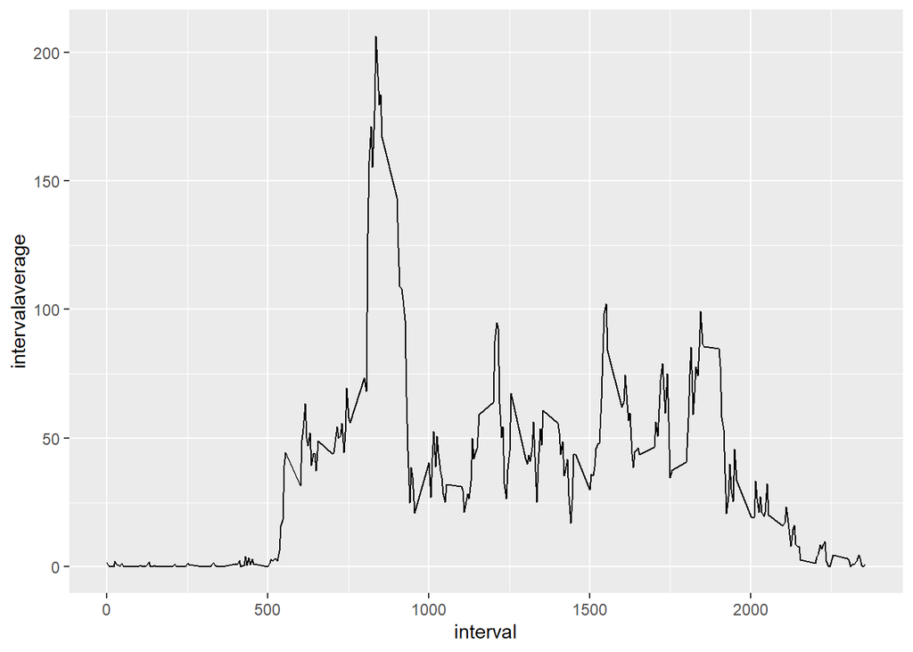

```r
by_interval = group_by(monitor_df, interval) %>%
                  summarize(intervalaverage = mean(steps, na.rm = TRUE))
ggplot(data = by_interval, aes(interval, intervalaverage)) +
      geom_line()
```

```r
dev.copy(png, file = "hist2.png",width=480,height=480,units="px")
```

```r
dev.off()
```

```r
max_interval = filter(by_interval, intervalaverage == max(by_interval$intervalaverage))$interval
```

The interval with the maximum number of steps is 835`

# Question 3

```r
#Missing values
nas = sum(is.na(monitor_df$steps))

#Creating a copy of our original dataframe
#Filling in NAs
monitor_df_filled = monitor_df
monitor_df_filled[is.na(monitor_df_filled)] = 0
```

We summarize for the sum,

```r
steps_per_day_filled = monitor_df_filled %>%
                  group_by(datetime) %>%
                  summarise(totalsteps = sum(steps, na.rm = TRUE),
                            meansteps = mean(steps, na.rm = TRUE),
                            mediansteps = median(steps, na.rm = TRUE)
                            )
```

```r
new_mean_steps = mean(steps_per_day_filled$meansteps, na.rm = TRUE)
new_median_steps = median(steps_per_day_filled$mediansteps, na.rm = TRUE)
```

### Figures

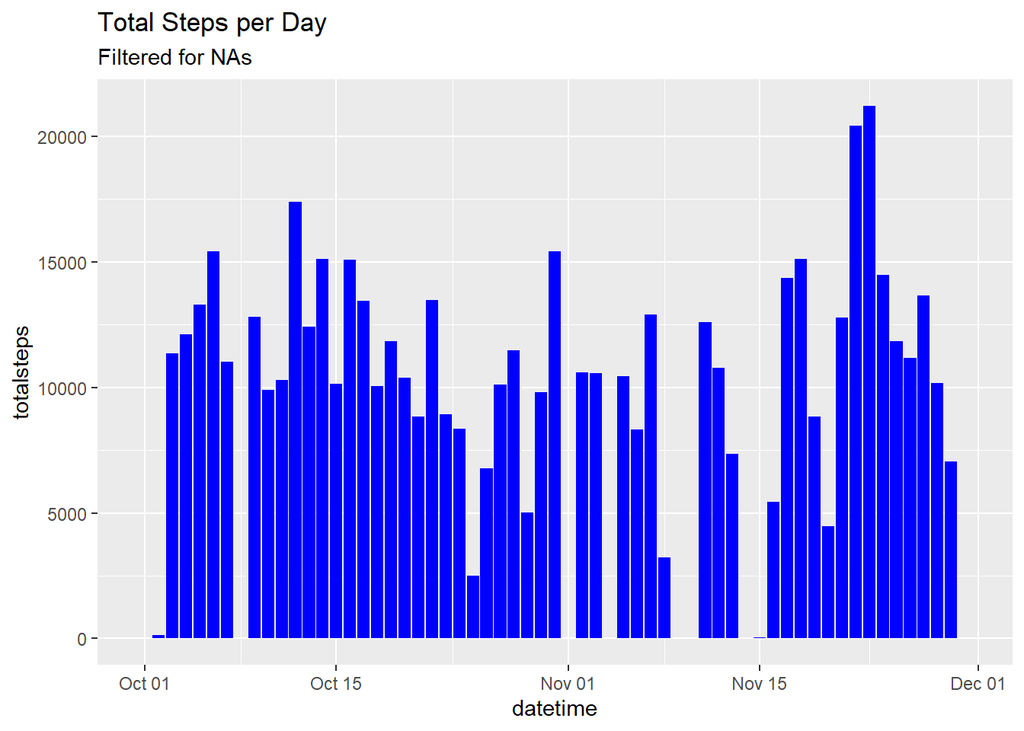

```r
ggplot(data = steps_per_day_filled, aes(datetime, totalsteps)) +
      geom_histogram(stat = "identity", fill = "blue") +
      labs(title = "Total Steps per Day", subtitle = "Filtered for NAs")
```

```r
dev.copy(png, file = "hist3.png",width=480,height=480,units="px")
```

```r
dev.off()
```

## Conclusion

There does not seem to be any noticeable change in the data as a result of the removal of NA values.

# Question 4 : Weekdays vs Weekends

We will add a new variable that specifies the day of week. This will allow us to filter for weekdays only and weekends only.

```r
#Getting the day of week
day_of_week = weekdays(monitor_df_filled$datetime)

#Looping through to replace labels with appropriate weekday or weekend values
weekday_weekend = sapply(day_of_week, function(x) {
                        if(x == "Saturday" | x == "Sunday") {x = "Weekend"}
                        else {x = "Weekday"}
                  })

#Adding variable to dataframe
monitor_df_filled$dayofweek = weekday_weekend
```

Next we will group by the two variables:  
- interval (step interval) - dayofweek

```r
dayofweek_steps = monitor_df_filled %>%
      group_by(dayofweek, interval) %>%
      summarize(totalsteps = mean(steps))
```

Finally we can create a multi-panel plot

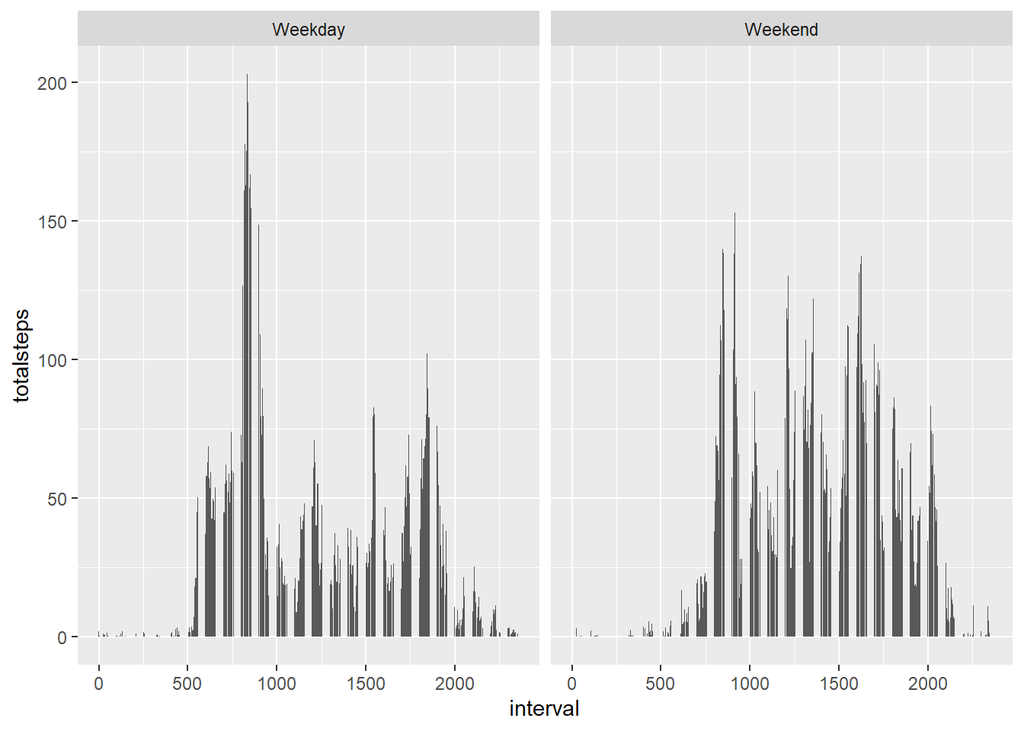

```r
ggplot(data = dayofweek_steps, aes(interval, totalsteps)) +
      geom_histogram(stat = "identity") +
      facet_grid(.~ dayofweek)
```

```r
dev.copy(png, file = "hist4.png",width=480,height=480,units="px")
```

```r
dev.off()
```